# Global Entrepreneurship Monitor

While entrepreneurship is a multifaceted phenomenon with many different meanings and definitions, GEM defines entrepreneurship as: "Any attempt at new business or new venture creation, such as self-employment, a new business organization, or the expansion of an existing business, by an individual, a team of individuals, or an established business" Thus, while GEM may see entrepreneurship rather narrowly as new business activity, it takes a broad view of what it recognizes (new) business activity to be. For example, unlike many official records of new business activity, GEM’s definition is not restricted to newly registered businesses. GEM thus adopts the occupational perspective of entrepreneurship, even though it looks further than individuals officially registered as self-employed. Entrepreneurship can also be seen from the behavioral perspective, for example by identifying employees within organizations who behave entrepreneurially (also known as intrapreneurship or corporate entrepreneurship). https://www.gemconsortium.org/wiki/1149

The NES questionnaire is used to collect the views of experts on a wide range of items, each of which was designed to capture a different dimension of a specific EFC: Entrepreneurial Finance. The availability of financial resources—equity and debt—for small and medium enterprises (SMEs) (including grants and subsidies). Government Policy. The extent to which public policies support entrepreneurship. This EFC has two components: a) Entrepreneurship as a relevant economic issue and b) Taxes or regulations are either size-neutral or encourage new and SMEs. Government Entrepreneurship Programs. The presence and quality of programs directly assisting SMEs at all levels of government (national, regional, municipal). Entrepreneurship Education. The extent to which training in creating or managing SMEs is incorporated within the education and training system at all levels. This EFC has two components: a) Entrepreneurship Education at basic school (primary and secondary) and b) Entrepreneurship Education at post-secondary levels (higher education such as vocational, college, business schools, etc.). R&D Transfer. The extent to which national research and development will lead to new commercial opportunities and is available to SMEs. Commercial and Legal Infrastructure. The presence of property rights, commercial, accounting and other legal and assessment services and institutions that support or promote SMEs. Entry Regulation. This EFC contains two components: a) Market Dynamics: the level of change in markets from year to year, and b) Market Openness: the extent to which new firms are free to enter existing markets. Physical Infrastructure. Ease of access to physical resources—communication, utilities, transportation, land or space—at a price that does not discriminate against SMEs. Cultural and Social Norms. The extent to which social and cultural norms encourage or allow actions leading to new business methods or activities that can potentially increase personal wealth and income. https://www.gemconsortium.org/wiki/1142

```python
%pip install pyreadstat

import pandas as pd

data = pd.read_spss('GEM 2019 APS Global National Level Data_27Feb2020.sav')
```

[output not shown]

[output cut: 21 more lines]

[output not shown]

```python
%pip install pyecharts
%pip install dash-bootstrap-components
```

```python
import pandas as pd
from dash import Dash, dcc, html, Input, Output
from dash.dependencies import State
import dash_bootstrap_components as dbc



app = Dash(__name__, external_stylesheets=[dbc.themes.BOOTSTRAP])

app.layout = html.Div([
    html.H1("Selected Key Indicator"),
    dcc.Dropdown(
        id="country-dropdown",
        options=[{"label": country, "value": country} for country in data["country"].unique()],
        value=data["country"].unique()[0]
    ),
    dbc.Row([
        dbc.Col(dcc.Graph(id="frfail19-gauge"), width=6),
        dbc.Col(dcc.Graph(id="futsup19-gauge"), width=6),
    ]),
    dbc.Row([
        dbc.Col(dcc.Graph(id="opport19-gauge"), width=6),
        dbc.Col(dcc.Graph(id="Knoent19-gauge"), width=6),
    ])
])

@app.callback(
    Output("frfail19-gauge", "figure"),
    [Input("country-dropdown", "value")]
)
def update_frfail19_gauge(country):
    filtered_data = data[data["country"] == country]
    frfail19 = filtered_data["Frfail19"].values[0]

    figure = {
        "data": [
            {
                "type": "indicator",
                "mode": "gauge+number",
                "value": frfail19,
                "title": {"text": "Fear of Failure (Frfail19)"},
                "gauge": {
                    "axis": {"range": [0, 100]},
                    "bar": {"color": "darkblue"},
                    "steps": [
                        {"range": [0, 50], "color": "lightgray"},
                        {"range": [50, 100], "color": "gray"}
                    ],
                    "threshold": {
                        "line": {"color": "red", "width": 4},
                        "thickness": 0.75,
                        "value": 80
                    }
                }
            }
        ],
        "layout": {
            "width": 400,
            "height": 300,
            "margin": {"l": 50, "r": 50, "t": 50, "b": 50}
        }
    }

    return figure

@app.callback(
    Output("futsup19-gauge", "figure"),
    [Input("country-dropdown", "value")]
)
def update_futsup19_gauge(country):
    filtered_data = data[data["country"] == country]
    futsup19 = filtered_data["Futsup19"].values[0]

    figure = {
        "data": [
            {
                "type": "indicator",
                "mode": "gauge+number",
                "value": futsup19,
                "title": {"text": "I'd start in 3 years (Futsup19)"},
                "gauge": {
                    "axis": {"range": [0, 100]},
                    "bar": {"color": "darkblue"},
                    "steps": [
                        {"range": [0, 50], "color": "lightgray"},
                        {"range": [50, 100], "color": "gray"}
                    ],
                    "threshold": {
                        "line": {"color": "red", "width": 4},
                        "thickness": 0.75,
                        "value": 80
                    }
                }
            }
        ],
        "layout": {
            "width": 400,
            "height": 300,
            "margin": {"l": 50, "r": 50, "t": 50, "b": 50}
        }
    }

    return figure

@app.callback(
    Output("opport19-gauge", "figure"),
    [Input("country-dropdown", "value")]
)
def update_opport19_gauge(country):
    filtered_data = data[data["country"] == country]
    opport19 = filtered_data["Opport19"].values[0]

    figure = {
        "data": [
            {
                "type": "indicator",
                "mode": "gauge+number",
                "value": opport19,
                "title": {"text": "Good conditions to start in 6 months (Opport19)"},
                "gauge": {
                    "axis": {"range": [0, 100]},
                    "bar": {"color": "darkblue"},
                    "steps": [
                        {"range": [0, 50], "color": "lightgray"},
                        {"range": [50, 100], "color": "gray"}
                    ],
                    "threshold": {
                        "line": {"color": "red", "width": 4},
                        "thickness": 0.75,
                        "value": 80
                    }
                }
            }
        ],
        "layout": {
            "width": 400,
            "height": 300,
            "margin": {"l": 50, "r": 50, "t": 50, "b": 50}
        }
    }

    return figure

@app.callback(
    Output("Knoent19-gauge", "figure"),
    [Input("country-dropdown", "value")]
)
def update_knowent_gauge(country):
    filtered_data = data[data["country"] == country]
    knowent = filtered_data["Knoent19"].values[0]

    figure = {
        "data": [
            {
                "type": "indicator",
                "mode": "gauge+number",
                "value": knowent,
                "title": {"text": "I know someone (Knoent19)"},
                "gauge": {
                    "axis": {"range": [0, 100]},
                    "bar": {"color": "darkblue"},
                    "steps": [
                        {"range": [0, 50], "color": "lightgray"},
                        {"range": [50, 100], "color": "gray"}
                    ],
                    "threshold": {
                        "line": {"color": "red", "width": 4},
                        "thickness": 0.75,
                        "value": 80
                    }
                }
            }
        ],
        "layout": {
            "width": 400,
            "height": 300,
            "margin": {"l": 50, "r": 50, "t": 50, "b": 50}
        }
    }

    return figure

# Run the app
if __name__ == "__main__":
    app.run_server()
```

[interactive chart not shown]

```python
import pandas as pd
from dash import Dash, dcc, html, Input, Output
import dash_bootstrap_components as dbc

app = Dash(__name__, external_stylesheets=[dbc.themes.BOOTSTRAP])


app.layout = html.Div([
    html.H1("Reason to Exit - Country in Region"),
    html.Div([
        html.Label("Select Region:"),
        dcc.Dropdown(
            id="region-dropdown",
            options=[{"label": region, "value": region} for region in data["REGION"].unique()],
            value=data["REGION"].unique()[0]
        )
    ]),
    html.Div([
        html.Label("Select Country:"),
        dcc.Dropdown(
            id="country-dropdown",
            options=[{"label": country, "value": country} for country in data["country"].unique()],
            value=data["country"].unique()[0]
        )
    ]),
    dbc.Row([
        dbc.Col(dcc.Graph(id="region-chart"), width=6),
        dbc.Col(dcc.Graph(id="country-chart"), width=6),
    ])
])

@app.callback(
    Output("region-chart", "figure"),
    [Input("region-dropdown", "value")]
)
def update_region_chart(region):
    filtered_data = data[data["REGION"] == region]
    avg_values = filtered_data[["EX19_RS1", "EX19_RS2", "EX19_RS3", "EX19_RS4", "EX19_RS5", "EX19_RS6", "EX19_RS7", "EX19_RS8", "EX19_RS11"]].mean()
    labels = ["opportunity to sell", "business not profitable", "problems getting finance", "another job or business opportunity", "exit was planned in advance", "retirement", "family or personal reasons", "incident", "government/tax policy/bureaucracy"]

    # Create the region chart
    figure = {
        "data": [
            {
                "type": "bar",
                "x": labels,
                "y": avg_values,
                "marker": {"color": "blue"}
            }
        ],
        "layout": {
            "title": "Average Values by Region",
            "xaxis": {"title": ""},
            "yaxis": {"title": "Average Value"}
        }
    }

    return figure

@app.callback(
    Output("country-chart", "figure"),
    [Input("country-dropdown", "value")]
)
def update_country_chart(country):
    filtered_data = data[data["country"] == country]
    values = filtered_data[["EX19_RS1", "EX19_RS2", "EX19_RS3", "EX19_RS4", "EX19_RS5", "EX19_RS6", "EX19_RS7", "EX19_RS8", "EX19_RS11"]].values[0]
    labels = ["opportunity to sell", "business not profitable", "problems getting finance", "another job or business opportunity", "exit was planned in advance", "retirement", "family or personal reasons", "incident", "government/tax policy/bureaucracy"]

    figure = {
        "data": [
            {
                "type": "bar",
                "x": labels,
                "y": values,
                "marker": {"color": "green"}
            }
        ],
        "layout": {
            "title": "Values by Country",
            "xaxis": {"title": ""},
            "yaxis": {"title": "Value"}
        }
    }

    return figure

# Run the app
if __name__ == "__main__":
    app.run_server()
```

[interactive chart not shown]

```python
import pandas as pd
from dash import Dash, dcc, html, Input, Output
from dash.dependencies import State
import dash_bootstrap_components as dbc

app = Dash(__name__, external_stylesheets=[dbc.themes.BOOTSTRAP])

app.layout = html.Div([
    html.H1("What Motivates Entrepreneurs? by country"),
    dcc.Dropdown(
        id="country-dropdown",
        options=[{"label": country, "value": country} for country in data["country"].unique()],
        value=data["country"].unique()[0]
    ),
    dbc.Row([
        dbc.Col(dcc.Graph(id="male-pie-chart"), width=6),
        dbc.Col(dcc.Graph(id="female-pie-chart"), width=6),
    ])
])

@app.callback(
    Output("male-pie-chart", "figure"),
    [Input("country-dropdown", "value")]
)
def update_male_pie_chart(country):
    filtered_data = data[data["country"] == country]
    male_values = filtered_data[["TEA19MMOT1", "TEA19MMOT2", "TEA19MMOT3", "TEA19MMOT4"]].values[0]
    labels = ["Make a Difference", "Make Money", "Family Tradition", "Dream Living"]

    figure = {
        "data": [
            {
                "type": "pie",
                "labels": labels,
                "values": male_values,
                "hole": 0.6,
                "hoverinfo": "label+percent",
                "textinfo": "labels",
                "textposition": "inside",
                "marker": {
                    "colors": ["#FF6384", "#36A2EB", "#FFCE56", "#8B008B"]
                }
            }
        ],
        "layout": {
            "title": "Male Motives",
            "width": 600,
            "height": 500
        }
    }

    return figure

@app.callback(
    Output("female-pie-chart", "figure"),
    [Input("country-dropdown", "value")]
)
def update_female_pie_chart(country):
    filtered_data = data[data["country"] == country]
    female_values = filtered_data[["TEA19FMOT1", "TEA19FMOT2", "TEA19FMOT3", "TEA19FMOT4"]].values[0]
    labels = ["Make a Difference", "Make Money", "Family Tradition", "Dream Living"]

    figure = {
        "data": [
            {
                "type": "pie",
                "labels": labels,
                "values": female_values,
                "hole": 0.6,
                "hoverinfo": "label+percent",
                "textinfo": "labels",
                "textposition": "inside",
                "marker": {
                    "colors": ["#FF6384", "#36A2EB", "#FFCE56", "#8B008B"]
                }
            }
        ],
        "layout": {
            "title": "Female Motives",
            "width": 600,
            "height": 500
        }
    }

    return figure

# Run the app
if __name__ == "__main__":
    app.run_server()
```

[interactive chart not shown]

```python
import pandas as pd
from dash import Dash, dcc, html, Input, Output
from dash.dependencies import State
import dash_bootstrap_components as dbc

app = Dash(__name__, external_stylesheets=[dbc.themes.BOOTSTRAP])

app.layout = html.Div([
    html.H1("what motivates entrepreneurs? by region"),
    dcc.Dropdown(
        id="region-dropdown",
        options=[{"label": region, "value": region} for region in data["REGION"].unique()],
        value=data["REGION"].unique()[0]
    ),
    dbc.Row([
        dbc.Col(dcc.Graph(id="male-pie-chart"), width=6),
        dbc.Col(dcc.Graph(id="female-pie-chart"), width=6),
    ])
])

@app.callback(
    Output("male-pie-chart", "figure"),
    [Input("region-dropdown", "value")]
)
def update_male_pie_chart(region):
    filtered_data = data[data["REGION"] == region]
    male_values = filtered_data[["TEA19MMOT1", "TEA19MMOT2", "TEA19MMOT3", "TEA19MMOT4"]].values[0]
    labels = ["Make a Difference", "Make Money", "Family Tradition", "Dream Living"]

    figure = {
        "data": [
            {
                "type": "pie",
                "labels": labels,
                "values": male_values,
                "hole": 0.6,
                "hoverinfo": "label+percent",
                "textinfo": "labels",
                "textposition": "inside",
                "marker": {
                    "colors": ["#FF6384", "#36A2EB", "#FFCE56", "#8B008B"]
                }
            }
        ],
        "layout": {
            "title": "Male Motives",
            "width": 600,
            "height": 500
        }
    }

    return figure

@app.callback(
    Output("female-pie-chart", "figure"),
    [Input("region-dropdown", "value")]
)
def update_female_pie_chart(region):
    filtered_data = data[data["REGION"] == region]
    female_values = filtered_data[["TEA19FMOT1", "TEA19FMOT2", "TEA19FMOT3", "TEA19FMOT4"]].values[0]
    labels = ["Make a Difference", "Make Money", "Family Tradition", "Dream Living"]

    figure = {
        "data": [
            {
                "type": "pie",
                "labels": labels,
                "values": female_values,
                "hole": 0.6,
                "hoverinfo": "label+percent",
                "textinfo": "labels",
                "textposition": "inside",
                "marker": {
                    "colors": ["#FF6384", "#36A2EB", "#FFCE56", "#8B008B"]
                }
            }
        ],
        "layout": {
            "title": "Female Motives",
            "width": 600,
            "height": 500
        }
    }

    return figure

# Run the app
if __name__ == "__main__":
    app.run_server()
```

[interactive chart not shown]

```python
import pandas as pd
from dash import Dash, dcc, html, Input, Output
import dash_bootstrap_components as dbc

app = Dash(__name__, external_stylesheets=[dbc.themes.BOOTSTRAP])

app.layout = html.Div([
    html.H1("New Business Owner-Manager Motives vs Established Business Owner-Manager Motives"),
    dcc.Dropdown(
        id="country-dropdown",
        options=[{"label": country, "value": country} for country in data["country"].unique()],
        value=data["country"].unique()[0]
    ),
    dbc.Row([
        dbc.Col(dcc.Graph(id="new-pie-chart"), width=6),
        dbc.Col(dcc.Graph(id="established-pie-chart"), width=6),
    ])
])

@app.callback(
    Output("new-pie-chart", "figure"),
    [Input("country-dropdown", "value")]
)
def update_new_pie_chart(country):
    filtered_data = data[data["country"] == country]
    nascent_values = filtered_data[["BB_19MOT1yes", "BB_19MOT2yes", "BB_19MOT3yes", "BB_19MOT4yes"]].values[0]
    labels = ["To make a difference", "To build great wealth", "To continue a family tradition", "To earn a living"]

    figure = {
        "data": [
            {
                "type": "pie",
                "labels": labels,
                "values": nascent_values,
                "hole": 0.6,
                "hoverinfo": "label+percent",
                "textinfo": "labels",
                "textposition": "inside",
                "marker": {
                    "colors": ["#FF6384", "#36A2EB", "#FFCE56", "#8B008B"]
                }
            }
        ],
        "layout": {
            "title": "Nascent Entrepreneur Motives",
            "width": 600,
            "height": 500
        }
    }

    return figure

@app.callback(
    Output("established-pie-chart", "figure"),
    [Input("country-dropdown", "value")]
)
def update_established_pie_chart(country):
    filtered_data = data[data["country"] == country]
    owner_values = filtered_data[["EB_19MOT1yes", "EB_19MOT2yes", "EB_19MOT3yes", "EB_19MOT4yes"]].values[0]
    labels = ["To make a difference", "To build great wealth", "To continue a family tradition", "To earn a living"]

    figure = {
        "data": [
            {
                "type": "pie",
                "labels": labels,
                "values": owner_values,
                "hole": 0.6,
                "hoverinfo": "label+percent",
                "textinfo": "labels",
                "textposition": "inside",
                "marker": {
                    "colors": ["#FF6384", "#36A2EB", "#FFCE56", "#8B008B"]
                }
            }
        ],
        "layout": {
            "title": "established Business -Manager Motives",
            "width": 600,
            "height": 500
        }
    }

    return figure

if __name__ == "__main__":
    app.run_server()
```

[interactive chart not shown]

```python
import pandas as pd
from dash import Dash, dcc, html, Input, Output
import dash_bootstrap_components as dbc

app = Dash(__name__, external_stylesheets=[dbc.themes.BOOTSTRAP])


app.layout = html.Div([
    html.H1("Business Sectors - Country in Region"),
    html.Div([
        html.Label("Select Region:"),
        dcc.Dropdown(
            id="region-dropdown",
            options=[{"label": region, "value": region} for region in data["REGION"].unique()],
            value=data["REGION"].unique()[0]
        )
    ]),
    html.Div([
        html.Label("Select Country:"),
        dcc.Dropdown(
            id="country-dropdown",
            options=[{"label": country, "value": country} for country in data["country"].unique()],
            value=data["country"].unique()[0]
        )
    ]),
    dbc.Row([
        dbc.Col(dcc.Graph(id="region-chart"), width=6),
        dbc.Col(dcc.Graph(id="country-chart"), width=6),
    ])
])

@app.callback(
    Output("region-chart", "figure"),
    [Input("region-dropdown", "value")]
)
def update_region_chart(region):
    filtered_data = data[data["REGION"] == region]
    avg_values = filtered_data[["Tea19s1p", "Tea19s2p", "Tea19s3p", "Tea19s4p"]].mean()
    labels = ["% EB Extractive sector", "% EB Transforming ", "% EB Business oriented services", "%  EB Consumer oriented services"]

    # Create the region chart
    figure = {
        "data": [
            {
                "type": "bar",
                "x": labels,
                "y": avg_values,
                "marker": {"color": "blue"}
            }
        ],
        "layout": {
            "title": "Average Values by Region",
            "xaxis": {"title": ""},
            "yaxis": {"title": "Average Value"}
        }
    }

    return figure

@app.callback(
    Output("country-chart", "figure"),
    [Input("country-dropdown", "value")]
)
def update_country_chart(country):
    filtered_data = data[data["country"] == country]
    values = filtered_data[["Tea19s1p", "Tea19s2p", "Tea19s3p", "Tea19s4p"]].values[0]
    labels = ["% EB Extractive ", "% EB Transforming ", "% EB Business oriented services", "% EB Consumer oriented services"]

    figure = {
        "data": [
            {
                "type": "bar",
                "x": labels,
                "y": values,
                "marker": {"color": "green"}
            }
        ],
        "layout": {
            "title": "Values by Country",
            "xaxis": {"title": ""},
            "yaxis": {"title": "Value"}
        }
    }

    return figure

if __name__ == "__main__":
    app.run_server()
```

[interactive chart not shown]

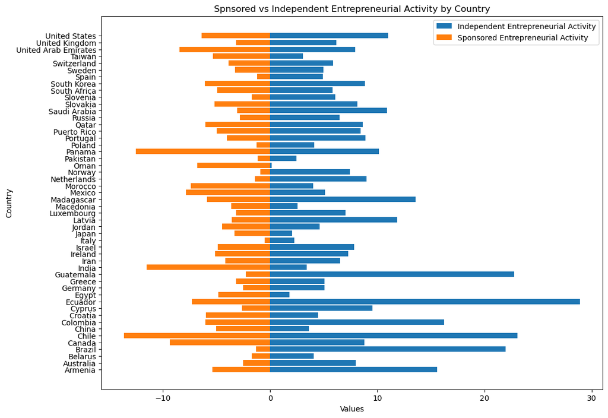

```python
import pandas as pd
import matplotlib.pyplot as plt

sorted_df = data.sort_values('country')

fig, ax = plt.subplots(figsize=(12, 9))

ax.barh(sorted_df['country'], sorted_df['TEA19IND'], label='Independent Entrepreneurial Activity')

ax.barh(sorted_df['country'], -sorted_df['TEA19SPON'], label='Sponsored Entrepreneurial Activity')

ax.set_ylabel('Country')

ax.set_xlabel('Values')

ax.set_title('Spnsored vs Independent Entrepreneurial Activity by Country')

ax.legend()
plt.show()
```

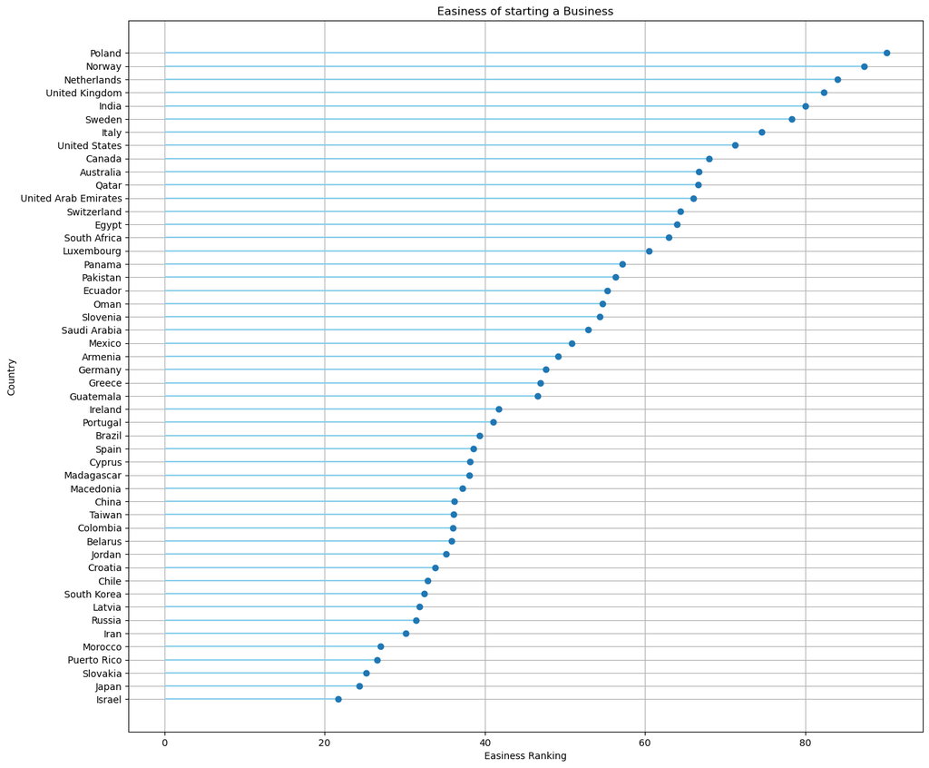

```python
import matplotlib.pyplot as plt

ordered_df = data.sort_values(by='EASYST19')
my_range = range(1, len(ordered_df.index) + 1)

fig, ax = plt.subplots(figsize=(15, 13.5))  # Increase the figure size by 150%
ax.hlines(y=my_range, xmin=0, xmax=ordered_df['EASYST19'], color='skyblue')
ax.plot(ordered_df['EASYST19'], my_range, "o")

ax.set_yticks(my_range)
ax.set_yticklabels(ordered_df['country'])
ax.set_title("Easiness of starting a Business")
ax.set_xlabel('Easiness Ranking')
ax.set_ylabel('Country')

ax.grid(True)
plt.show()
```

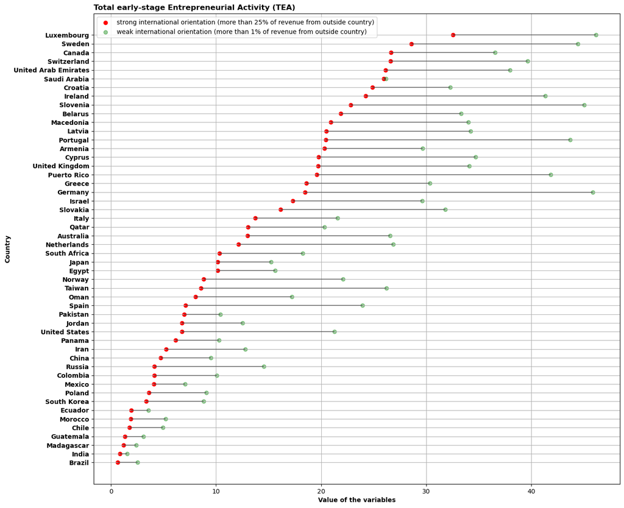

```python
ordered_df = data.sort_values(by=['TEAexpst'])
my_range = range(1, len(ordered_df.index) + 1)

fig, ax = plt.subplots(figsize=(15, 13.5))
ax.hlines(y=my_range, xmin=ordered_df['TEAexpst'], xmax=ordered_df['TEAexpwk'], color='black', alpha=0.4)
ax.scatter(ordered_df['TEAexpst'], my_range, color='red', alpha=1, label='strong international orientation (more than 25% of revenue from outside country)')
ax.scatter(ordered_df['TEAexpwk'], my_range, color='green', alpha=0.4, label='weak international orientation (more than 1% of revenue from outside country)')
ax.legend()

ax.set_yticks(my_range)
ax.set_yticklabels(ordered_df['country'], fontweight='bold')
ax.set_title("Total early-stage Entrepreneurial Activity (TEA)", loc='left', fontweight='bold')
ax.set_xlabel('Value of the variables', fontweight='bold')
ax.set_ylabel('Country', fontweight='bold')

ax.grid(True)
plt.show()
```

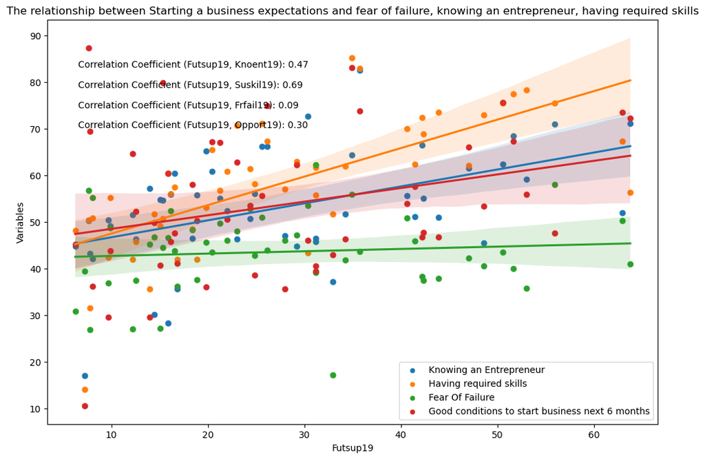

```python
%pip install scipy
import seaborn as sns
import pandas as pd
from scipy.stats import pearsonr
import matplotlib.pyplot as plt

# Assuming 'data' is a DataFrame that you've already defined
fig, ax = plt.subplots(figsize=(12, 8))

# Scatter plots
sns.scatterplot(data=data, x='Futsup19', y='Knoent19', ax=ax)
sns.scatterplot(data=data, x='Futsup19', y='Suskil19', ax=ax)
sns.scatterplot(data=data, x='Futsup19', y='Frfail19', ax=ax)
sns.scatterplot(data=data, x='Futsup19', y='Opport19', ax=ax)

# Regression plots
sns.regplot(data=data, x='Futsup19', y='Knoent19', ax=ax)
sns.regplot(data=data, x='Futsup19', y='Suskil19', ax=ax)
sns.regplot(data=data, x='Futsup19', y='Frfail19', ax=ax)
sns.regplot(data=data, x='Futsup19', y='Opport19', ax=ax)

# Pearson correlation coefficients
corr_coef1, _ = pearsonr(data['Futsup19'], data['Knoent19'])
corr_coef2, _ = pearsonr(data['Futsup19'], data['Suskil19'])
corr_coef3, _ = pearsonr(data['Futsup19'], data['Frfail19'])
corr_coef4, _ = pearsonr(data['Futsup19'], data['Opport19'])

# Descriptive statistics
descriptive_stats1 = data[['Futsup19', 'Knoent19']].describe()
descriptive_stats2 = data[['Futsup19', 'Suskil19']].describe()
descriptive_stats3 = data[['Futsup19', 'Frfail19']].describe()
descriptive_stats4 = data[['Futsup19', 'Opport19']].describe()

# Text annotations for correlation coefficients
ax.text(0.05, 0.90, f'Correlation Coefficient (Futsup19, Knoent19): {corr_coef1:.2f}', transform=ax.transAxes, verticalalignment='top')
ax.text(0.05, 0.85, f'Correlation Coefficient (Futsup19, Suskil19): {corr_coef2:.2f}', transform=ax.transAxes, verticalalignment='top')
ax.text(0.05, 0.80, f'Correlation Coefficient (Futsup19, Frfail19): {corr_coef3:.2f}', transform=ax.transAxes, verticalalignment='top')
ax.text(0.05, 0.75, f'Correlation Coefficient (Futsup19, Opport19): {corr_coef4:.2f}', transform=ax.transAxes, verticalalignment='top')

# Set labels and title
ax.set_xlabel('Futsup19')
ax.set_ylabel('Variables')
ax.set_title('The relationship between Starting a business expectations and fear of failure, knowing an entrepreneur, having required skills')

# Show legend
plt.legend(['Knowing an Entrepreneur', 'Having required skills', 'Fear Of Failure', "Good conditions to start business next 6 months"])

# Show the plot
plt.show()
```